# Predicting male fertility from personal risk factors

iNLyze  
Wed May 11 01:19:07 2016

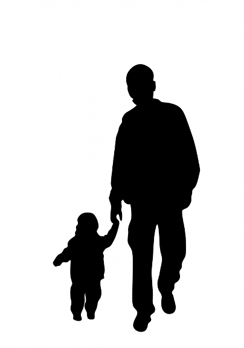

### Significance of fertility

“Infertility […] is also a significant clinical problem today, which affects 8–12% of couples worldwide. Of all infertility cases, approximately 40–50% is due to “male factor” infertility and as many as 2% of all men will exhibit suboptimal sperm parameters.” [Kumar et al](http://www.ncbi.nlm.nih.gov/pmc/articles/PMC4691969/) *J Hum Reprod Sci.* 2015 Oct-Dec; 8(4): 191–196.

- Direct analysis of sperm quality requires expert knowledge and specialized equipment
- Sperm quality is often affected by a number of risk factors
- Predicting male fertility from such factors may give a first indication
- Could save cost and time by focusing more in-depth analysis on persons who are more likely whose fertility might be altered.

### Data and model building

## How the data was obtained:

- Data was originally created as part of [Gil et al](https://www.researchgate.net/profile/Joaquin_De_Juan/publication/230868076_Predicting_seminal_quality_with_artificial_intelligence_methods/links/09e415058f10cc3081000000.pdf)
- A subset of the original data (100 x 10) is available at [UCI](https://archive.ics.uci.edu/ml/datasets/Fertility)

## How the model was built:

- The data set was split into training and a test set (70%/30%, respectively)
- A random forest model was built using 632 Bootstrapping with 100 iterations and 100 repeats
- This model achieved an accuracy of 93%
- About comparable to performance achieved with best model in original publication

### Model performance

- Data set imbalanced, classes N, O have 88, 12 occurences
- Small data set, only 100 samples
- 10 dimensions, original publication used 34 dimensions

```
Confusion Matrix and Statistics

          Reference
Prediction  N  O
         N 26  2
         O  0  1

               Accuracy : 0.931
                 95% CI : (0.7723, 0.9915)
    No Information Rate : 0.8966
    P-Value [Acc > NIR] : 0.4109

                  Kappa : 0.4727
 Mcnemar's Test P-Value : 0.4795

            Sensitivity : 0.33333
            Specificity : 1.00000
         Pos Pred Value : 1.00000
         Neg Pred Value : 0.92857
             Prevalence : 0.10345
         Detection Rate : 0.03448
   Detection Prevalence : 0.03448
      Balanced Accuracy : 0.66667

       'Positive' Class : O
```

### How to use the application

- Type in require information and press submit
- Data is normalized to match format of data set
- To save time model is loaded from file, only prediction is made
- Output has been chosen to be as neutral as possible due to the very personal nature of the matter.
- Note: Age is confined to inputs only between 18 - 36 years due to nature of study (and relavent age when fatherhood is desired by large proportion of men). Predicting outside this age interval is potentially unreliable.